# Project 2 - Titanic

## Titanic Data

Question: 1.How does the passenger class, sex of passengers affect their survival rate? 2.What is the relation between age of the passengers and their survival?

```python
#Loading the data
import pandas as pd
titanic_df = pd.read_csv('titanic-data.csv')
```

```python
titanic_df.head(8)
```

|  | PassengerId | Survived | Pclass | Name | Sex | Age | SibSp | Parch | Ticket | Fare | Cabin | Embarked |
| --- | --- | --- | --- | --- | --- | --- | --- | --- | --- | --- | --- | --- |
| 0 | 1 | 0 | 3 | Braund, Mr. Owen Harris | male | 22.0 | 1 | 0 | A/5 21171 | 7.2500 | NaN | S |
| 1 | 2 | 1 | 1 | Cumings, Mrs. John Bradley (Florence Briggs Th... | female | 38.0 | 1 | 0 | PC 17599 | 71.2833 | C85 | C |
| 2 | 3 | 1 | 3 | Heikkinen, Miss. Laina | female | 26.0 | 0 | 0 | STON/O2. 3101282 | 7.9250 | NaN | S |
| 3 | 4 | 1 | 1 | Futrelle, Mrs. Jacques Heath (Lily May Peel) | female | 35.0 | 1 | 0 | 113803 | 53.1000 | C123 | S |
| 4 | 5 | 0 | 3 | Allen, Mr. William Henry | male | 35.0 | 0 | 0 | 373450 | 8.0500 | NaN | S |
| 5 | 6 | 0 | 3 | Moran, Mr. James | male | NaN | 0 | 0 | 330877 | 8.4583 | NaN | Q |
| 6 | 7 | 0 | 1 | McCarthy, Mr. Timothy J | male | 54.0 | 0 | 0 | 17463 | 51.8625 | E46 | S |
| 7 | 8 | 0 | 3 | Palsson, Master. Gosta Leonard | male | 2.0 | 3 | 1 | 349909 | 21.0750 | NaN | S |

```python
#printing basic information
total_passengers = len(titanic_df)
male_passengers = titanic_df[titanic_df['Sex']=='male']
female_passengers = titanic_df[titanic_df['Sex']=='female']
survived_passengers = titanic_df[titanic_df['Survived']== 1]
dead_passengers = titanic_df[titanic_df['Survived']== 0]
print 'Total number of passengers:{}'.format(total_passengers)
print 'Total number of male passengers:{}'.format(len(male_passengers))
print 'Total number of female passengers:{}'.format(len(female_passengers))
print 'Number of passengers who survived:{}'.format(len(survived_passengers))
print 'Number of passengers who didnot survive:{}'.format(len(dead_passengers))
```

```
Total number of passengers:891
Total number of male passengers:577
Total number of female passengers:314
Number of passengers who survived:342
Number of passengers who didnot survive:549
```

```python
def survivors_per_class(Pclass):
    #number of passengers in each class
    passengers_per_class = titanic_df[titanic_df['Pclass']==Pclass]
    no_passengers = len(passengers_per_class)

    #male survivors proportion per class
    male_per_class = len(titanic_df[(titanic_df['Pclass']==Pclass) & (titanic_df['Sex']=='male')])
    malesurvivors_per_class = len(titanic_df[(titanic_df['Survived']==1) & (titanic_df['Pclass']==Pclass) & (titanic_df['Sex']=='male')])
    malesurvivors_proportion = malesurvivors_per_class / float(male_per_class)
    malesurvivors_percentage = round((malesurvivors_proportion*100), 2)

    #female survivors proportion per class
    female_per_class = len(titanic_df[(titanic_df['Pclass']==Pclass) & (titanic_df['Sex']=='female')])
    femalesurvivors_per_class = len(titanic_df[(titanic_df['Survived']==1) & (titanic_df['Pclass']==Pclass) & (titanic_df['Sex']=='female')])
    femalesurvivors_proportion = femalesurvivors_per_class / float(female_per_class)
    femalesurvivors_percentage = round((femalesurvivors_proportion*100), 2)

    #total survival percentage
    survivors_per_class = round((malesurvivors_per_class+femalesurvivors_per_class) / float(no_passengers)*100, 2)
    percent_of_total = round((malesurvivors_per_class+femalesurvivors_per_class) / float(len(survived_passengers))*100, 2)

    #print the results
    print 'Number of female survivors in class {} is {}. This is {}% of the total class {} females'.format(Pclass,femalesurvivors_per_class,femalesurvivors_percentage,Pclass)
    print 'Number of male survivors in class {} is {}. This is {}% of the total class {} males'.format(Pclass,malesurvivors_per_class,malesurvivors_percentage,Pclass)
    print 'Survival percentage of class {} is {}%. This is {}% of the total survivors'.format(Pclass,survivors_per_class,percent_of_total)
    print ' '

    return malesurvivors_per_class, femalesurvivors_per_class

malesurvivors_pclass1, femalesurvivors_pclass1 = survivors_per_class(1)
malesurvivors_pclass2, femalesurvivors_pclass2 = survivors_per_class(2)
malesurvivors_pclass3, femalesurvivors_pclass3 = survivors_per_class(3)
```

```
Number of female survivors in class 1 is 91. This is 96.81% of the total class 1 females
Number of male survivors in class 1 is 45. This is 36.89% of the total class 1 males
Survival percentage of class 1 is 62.96%. This is 39.77% of the total survivors

Number of female survivors in class 2 is 70. This is 92.11% of the total class 2 females
Number of male survivors in class 2 is 17. This is 15.74% of the total class 2 males
Survival percentage of class 2 is 47.28%. This is 25.44% of the total survivors

Number of female survivors in class 3 is 72. This is 50.0% of the total class 3 females
Number of male survivors in class 3 is 47. This is 13.54% of the total class 3 males
Survival percentage of class 3 is 24.24%. This is 34.8% of the total survivors
```

We can observe that survival percentage of females is very high compared to the males in each class. So we could say that the chances of a person's survival would be more if that person were a female.

Also we could say that first class passengers were given the first preference to take the lifeboats followed by the second class passengers and the third.

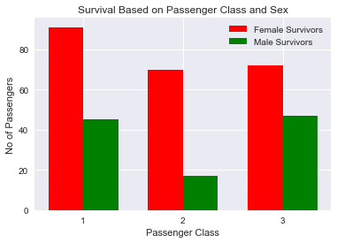

```python
#plotting the above results
%pylab inline
import matplotlib.pyplot as plt
import seaborn as sns
tick_list = sorted(list(data['Pclass'].unique()))
index = np.arange(len(tick_list))
width = .35

malesurvived_pclass = [malesurvivors_pclass1, malesurvivors_pclass2, malesurvivors_pclass3]
femalesurvived_pclass = [femalesurvivors_pclass1, femalesurvivors_pclass2, femalesurvivors_pclass3]

p1 = plt.bar(index, femalesurvived_pclass, width, color='r', label='Female Survivors')
p2 = plt.bar(index + width, malesurvived_pclass, width, color='g', label='Male Survivors')

plt.xlabel('Passenger Class')
plt.ylabel('No of Passengers')
plt.xticks(index + width/2., tick_list)
plt.title('Survival Based on Passenger Class and Sex')
plt.legend()

plt.show()
```

```python
#No of records with missing age value
print titanic_df['Age'].isnull().values.ravel().sum()
```

```
177
```

```python
titanicsurvivors_age = survived_passengers['Age'].fillna(np.random.randint(0,80))
titanicdead_age = dead_passengers['Age'].fillna(np.random.randint(0,80))
```

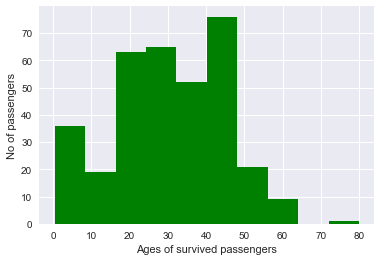

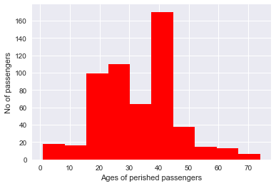

```python
#plotting the ages of the survivors and non-survivors
plt.hist(titanicsurvivors_age,color ='green')
plt.xlabel('Ages of survived passengers')
plt.ylabel('No of passengers')
plt.show()
plt.hist(titanicdead_age,color = 'red')
plt.xlabel('Ages of perished passengers')
plt.ylabel('No of passengers')
plt.show()
```

It can be seen that children, namely passengers under ages 20, had a good survival rate.